# Lab4: Correlation Analysis and Building of Linear Regression Model

Dovydas Klimas E1863

## **Task**: build a linear regression model, explain the impact of advertising on sales, and predict new values for sales.

Based on this analysis, suggest a marketing plan for next year that will result in high product sales.

### Sales - a response variable (Y), other variables - predictors (X)

More info about variables you can find in the file “data description.txt”.

# 1. (1 point) Data sample preparation

- Import data: if the last digit of vidko (student’s code) is odd, then choose file “marketing_odd_.csv”; otherwise, choose “marketing_even_.csv”
- Generate your data set by randomly selecting 50% of instances (rows)
- Check: data type, outliers, missing values

```r
library(dplyr)
# data<-read.csv2("XXXXX.csv")
# set.seed(vidko);  # vidko - digits from student's ID.
# my_data <- data[sample(nrow(data),0.5*nrow(data)), ]
vidko = 1863;
data<-read.csv("marketing_odd_.csv");
set.seed(vidko);  # vidko - digits from student's ID.
my_data <- data[sample(nrow(data),0.5*nrow(data)), ];

class(my_data)
```

```
## [1] "data.frame"
```

```r
str(my_data)
```

```
## 'data.frame':    1000 obs. of  5 variables:
##  $ sales        : num  17 17 15.4 16.9 17.1 ...
##  $ socialnetwork: num  28.9 27.4 26.4 27.6 28.2 ...
##  $ google       : num  126 127 125 127 126 ...
##  $ youtube      : num  179 176 177 177 174 ...
##  $ newspaper    : num  64 20.2 73.6 38.7 36.8 ...
```

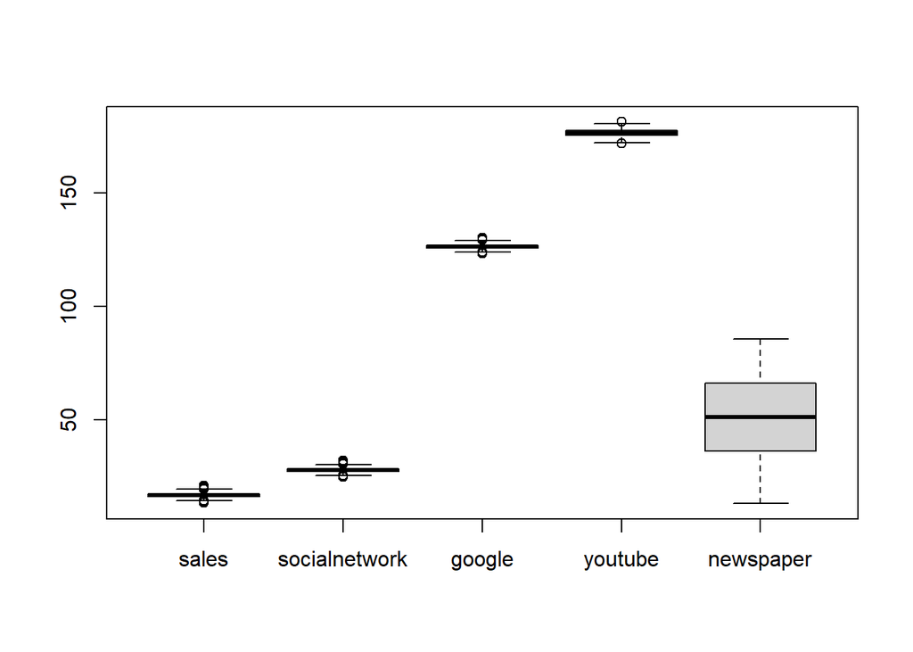

```r
boxplot(my_data)
```

```r
outliers = 0;
for (x in 1:ncol(my_data))
{
  values = my_data[,x][my_data[,x] %in% boxplot.stats(my_data[,x])$out]
  outliers = outliers + length(values)

}
cat("Outliers: ", outliers)
```

```
## Outliers:  46
```

```r
NAsum = as.data.frame(colSums(is.na(my_data)))
NAsum
```

```
##               colSums(is.na(my_data))
## sales                               0
## socialnetwork                       0
## google                              0
## youtube                             0
## newspaper                           0
```

```r
#cat("NA values: ", NAsum)
```

- Split your data into two data sets: train set and test set using proportions 80:20 based on the slides about model building

```r
# set.seed(vidko) # vidko - your student code
# row.number <- sample(1:nrow(my_data), 0.8*nrow(my_data))
# train = my_data[row.number,]
# test = my_data[-row.number,]
# dim(train)
# dim(test)

set.seed(vidko) # vidko - your student code
row.number = sample(1:nrow(my_data), 0.8*nrow(my_data))
train = my_data[row.number, ]
test = my_data[-row.number, ]
dim(train)
```

```
## [1] 800   5
```

```r
dim(test)
```

```
## [1] 200   5
```

# 2. (1 point) Correlation Analysis

- Explore the existence of linear relationships between variables by drawing scatterplot.
- Determine Pearson correlations

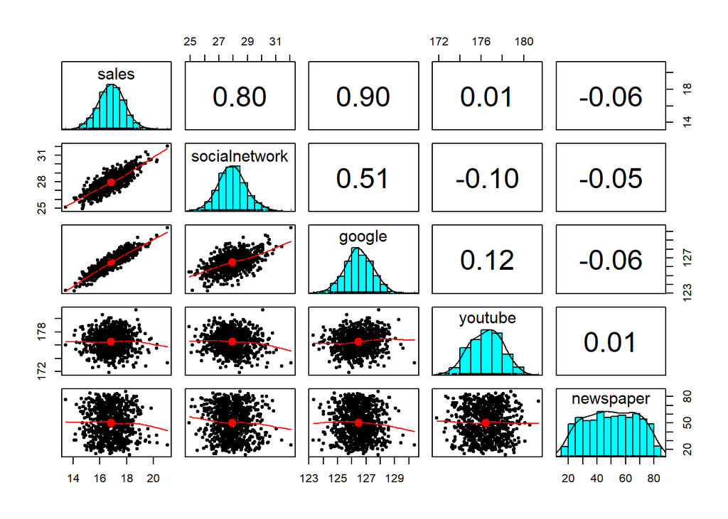

```r
# psych::pairs.panels(train,  method = "pearson", density = TRUE)
# cor(train,  method = "pearson") # or corrplot

psych::pairs.panels(train,  method = "pearson", density = TRUE)
```

```r
cor(train,  method = "pearson") # or corrplot
```

```
##                     sales socialnetwork      google     youtube   newspaper
## sales          1.00000000    0.80354685  0.89985314  0.01450898 -0.05815484
## socialnetwork  0.80354685    1.00000000  0.50642913 -0.09823131 -0.04697686
## google         0.89985314    0.50642913  1.00000000  0.11800829 -0.05577331
## youtube        0.01450898   -0.09823131  0.11800829  1.00000000  0.01062063
## newspaper     -0.05815484   -0.04697686 -0.05577331  0.01062063  1.00000000
```

- Are the any pairs of variables whose relationship could not be explained linearly? pairs whose relationship of variable that can’t be explainer linearly are (sales with youtube, newspaper); (socialnetwork with youtube, newspaper), (google with youtube and newspapers) (youtube with newspaper)  
- What variables correlate mostly? do not correlate? Variables that correlate mostly are google and sales. Variables that do not correlate are (sales with youtube, newspaper); (socialnetwork with youtube, newspaper), (google with youtube and newspapers) (youtube with newspaper) because their correlation coefficients are in big difference.